# Selected Sections from Chapter 10: 10.1-10.2 & 10.6-10.7

© Scott Robison 2021 all rights reserved.

## Introduction to Hypothesis Testing

> Start by [Reading](https://github.com/chqngh-berkeley/personal/blob/master/Mathematical%20Statistics%20-%207th%20Edition%20-%20Wackerly.pdf) pages 488-494 & 513-519 from the text.

**The concept of evidence collection**

A well-known story goes something like this: Four students missed the midterm for their statistics class. They went to the professor together and said, “Please let us make up the exam. We carpool together, and on our way to the exam, we got a flat tire. That’s why we missed the exam.” The professor didn’t believe them, but instead of arguing he said, “Sure, you can make up the exam. Be in my office tomorrow at 8.”

The next day, they met in his office. He sent each student to a separate room and gave them an exam. The exam consisted of only one question: “Which tire?” We don’t know the outcome of this story, but let’s imagine that all four students answer, “left rear tire.” The professor is surprised. He had assumed that the students were lying. “Maybe,” he thinks, “they just got lucky. After all, if they just guessed, they could still all choose the same tire.” But then he does a quick calculation and figures out that the probability that all four students will guess the same tire is only 1.6%. Reluctantly, he concedes that the students were not lying, and now he must give all of them an A on the exam.

The statistics professor has just performed a hypothesis test. **Hypothesis testing is a formal procedure that enables us to choose between two hypotheses when we are uncertain about our measurements**. We call hypothesis testing a formal procedure because it is based on particular terminology and a rather well specified set of steps.

However, we hope to show you that this “formal” procedure has a generous helping of common sense supporting it.

**Start with: A Pair of Hypotheses**

In a formal hypothesis test, hypotheses are always statements about population parameters, $\theta_0$.

> Remember you would never make a guess at something you already know, hypothesis, $\theta_0$, are always on parameters, $\theta$, not statistics, $\widehat{\theta}_n$. We use the statistic as evidence to justify our hypothesis!

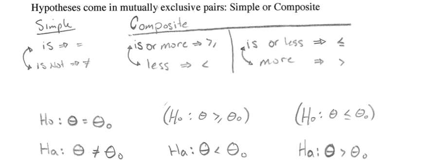

The **null hypothesis**, which we write $H_0$ (and pronounce “H-naught” or simply “the null hypothesis”), is the conservative, status-quo, business-as-usual statement about a population parameter. In the context of researching new ideas, the null hypothesis often represents “no change,” “no effect,” or “no difference.”

The **alternative hypothesis**, $H_a$ (pronounced “H-A”), is the research hypothesis. It is usually a statement about the value of a parameter that we hope to demonstrate is true.

**The most important step of a formal hypothesis test is choosing the hypotheses**. In fact, there are really only two steps of a formal hypothesis test that a computer cannot do, and this is one of those steps. (The other step is checking to make sure that the conditions necessary for the probability calculations to be valid are satisfied.)

Hypothesis tests are like criminal trials. In a criminal trial, two hypotheses are placed before the jury: The defendant is not guilty, or he is guilty. These hypotheses are not given equal weight, however. The jury is told to assume the defendant is not guilty until the evidence overwhelmingly suggests this is not so. (Defendants charged with a crime in the Canada must be found guilty “beyond all reasonable doubt.”)

> The null hypothesis is, by default, assumed true. This means when no substantial evidence is provided the null is “not dethroned” this does not guarantee the truthfulness of the null, rather just that at the moment we can’t discount it… Should we then claim $H_0$ is true? Or that we failed to say $H_0$ is false?

Hypothesis tests follow the same principles. The statistician plays the role of the prosecuting attorney, who hopes to show that the defendant is guilty. The hypothesis that the statistician or researcher hopes to establish, called the ‘claim,’ plays the role of the alternative hypothesis. The null hypothesis is chosen to be a neutral, noncontroversial statement. Just as in a jury trial, where we ask the jury to believe that the defendant is not guilty unless the evidence against this belief is overwhelming, we will believe that the null hypothesis is true in the beginning. But once we examine the evidence, we may reject this belief if the evidence is overwhelmingly against it.

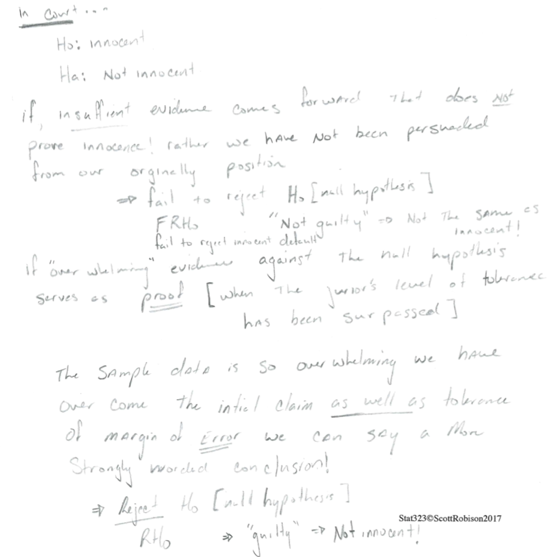

**Using Mathematical Signs to set up Hypothesis**

An extremely powerful tool for setting up the correct hypotheses is to consider the condition of the statement given as it relates to the following mathematical notation.

$$(=,\le,\ge,\text{ or } \ne,>,<)$$

**Any sign that includes the equality $(=,\le,\ge)$ must be located in the null hypothesis**!

**Conversely, the corresponding non-equal sign $(\ne,>,<)$ must be located in the alternative hypothesis!** Or vice-versa.

> The null hypothesis always contains the equal sign. $(=,\le,\ge)$ It is also acceptable to always write it with only the equal sign

### Example 1

Consider the following statements. In each, state the appropriate null and alternative hypothesis.

1. One flips a coin $n$-times to test the claim that the coin is a ‘fair’ coin.
2. An Alberta doctor claims that the average cost of a Multiple Resonance Imaging (MRI) test is less than $1,200.
3. An economist wishes to test if the March unemployment rate in Alberta - the percentage of able-working Albertan’s - is higher than February’s Alberta unemployment rate of 6.4%.
4. Researchers believe that a new chemotherapy treatment will prolong the lifetime of patients afflicted with liver cancer. The mean/average survival time of liver cancer patients using the current chemotherapy regime is 4.3 months.
5. An epidemiologist wants to see if better detection methods and improved treatment has decreased the Stage II breast cancer fatality rate, which is approximately 15%.

### Solution

[video not shown]

**Assessing which Hypothesis your Sample Data Supports**

As we saw with confidence intervals it is necessary to assign **a suitable amount of allowable error/tolerance to deviation**, to ensure that the implications of our calculations say something of significance. This **“level of significance,”** again is given the Greek letter $\alpha$ the same as we saw in confidence intervals.

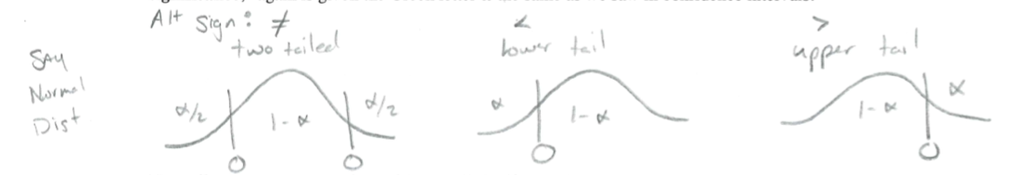

Naturally, we want a procedure with a small significance level since this does represent error and, we don’t want to make mistakes too often. How small? Often $\alpha=0.05$.

We then we aggregate the information the sample gives us into a standardized scale called the **Test Statistic**.

Finally, we convert that Test Statistic into a **p-value**, which is compared to the significance level, $\alpha$.

> P-value can be difficult to understand, it refers to the possibility of repeating the sampling process and comparing the likelihood of those theoretical results with what did happen during the sample you do have…

> It reminds me of deciding how you want to deal with certain situations before you are actually faced with those situations.

> Ex. If my favorite brand of Ginger-Ale is on sale for a great price, I will buy an exorbitant quantity because, I expect, when I go shopping later I would not expect it to be priced this way again.

> Then p-value is defined as the probability that, if the H_o is true, you could collect another sample as rare/extreme or more rare/extreme then the sample that you have.

> $$\text{p-value}=P(f_X (x)[(\ne,>,<)\text{ sign in alternative hyp.}] X |H_0 \text{ is true})$$
> $$\text{ where }X\text{ is the Test Statistic}$$

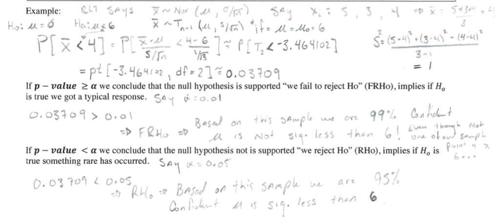

If **p-value $\ge\alpha$** we conclude that the null hypothesis is supported “we fail to reject $H_0$” (FRHo), implies if $H_0$ is true we got a typical response.

If **p-value $<\alpha$** we conclude that the null hypothesis not is supported “we reject $H_0$” (RHo), implies if $H_0$ is true something rare has occurred.

### The Language We Use

It is improper (maybe even impolite/incorrect!) to say that you have “accepted” the null hypothesis when your p-value is bigger than 0.05. Instead, we say **“We have failed to reject Ho”** or “We cannot reject Ho.” The reason for this is that several factors might make it difficult to determine whether the null hypothesis is false.

**Coming to Incorrect Decisions**

Mistakes are an inevitable part of the hypothesis-testing process. The trick is not to make them too often. (Not talking about mathematically mistakes here, we are referring to mistakes of conclusion.)

One mistake we might make is to reject the null hypothesis when it is true. This is called **a Type I error**. For example, recall the default or null hypothesis of a court trial is that the defendant is ‘innocent.’ If a truly innocent defendant is found guilty this is considered a type I error.

However, we might mistakenly, fail to reject the null hypothesis when it is actually false. This is called **a Type II error**. In our example, this would be described as finding a truly guilty defendant innocent.

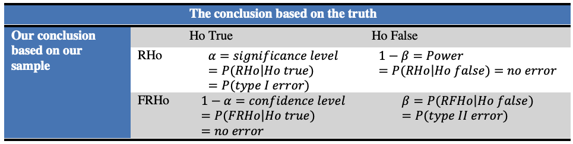

### The Trade-off between Significance Level and Power

We are free to choose any value we wish for the significance level. Typically, we set this probability at 0.05, but sometimes we go as low as 0.01. But why don’t we make it arbitrarily small? Say 0.0000001? That way, we’d almost never make this mistake.

We can’t make the significance level as small as we would like because we have a price to pay. The price is that if we make the significance level smaller, then the power gets smaller too!

To see this, think about our criminal justice example. We can make the significance level, the probability of convicting an innocent man, $\alpha=0$ by following a simple rule: Free every defendant. If everyone goes free, then it is impossible to convict an innocent person because you are convicting no one. But now the power—the probability of correctly convicting a guilty person is: $1-\beta=0$%.

> Know that although $\alpha$ and $\beta$ are inversely related $1-\alpha$ is not how we calculate $\beta$

There is a way to have both α and β both increase/decrease instead of the inverse relationship typically associated with them…can you think of what it is?

- The only way to simultaneously lower both $\alpha$ & $\beta$ is to increase the sample size, $n$! Bigger samples should reduce the variacne of consistant estimators and decrease risk of error!

[video not shown]

Looking for [R code provided in Examples? right click “save linked file”](https://people.ucalgary.ca/~sarobiso/323/text%20soltutions/Intro%20to%20hypothesis%20testing.R)

### Example 2

A political candidate is pondering running for public office. This candidate will only do so if there is some indication that he will not receive less than 50% of the vote.

A random sample of 15 voters is taken. **If three or less of the voters say they will vote for this candidate, then he will not run for public office.**

1. State the most appropriate null and alternative hypothesis.
2. Defining $X$ as the number of voters, out of 15, that would vote for this particular candidate, find $\alpha$, the probability of committing a Type I error. [Define $X$ as the number of voters, out of 15 randomly chosen that would vote for this particular candidate, the rejection region is: $X∶ X \le 3$. ]
3. Unbeknownst to the interested candidate, he is to receive 40% of the vote. What is the probability of concluding from the sample of 15 that he will receive at least 50% of the vote? Is this a good thing? Re-write the meaning of this in context but in your own words?
4. Returning to parts (b) and (c): consider a new suggested decision rule which states the null hypothesis in (a) can be rejected if $X \le 5$. Find the probability of committing a Type II error with the rejection region $\{X∶ X \le 5\}$. How does this impact the possible errors? Which error would you prefer?
5. A random sample of 15 was taken, of which 8 voters said they would voter for this particular candidate. What decision can be made about the null hypothesis in (a)? Identify the Test Statistic, give the p-value and interpret it.
6. Does your p-value change when considering rejection region proposed in part (b) vs. part (d)?
- 1. What if $H_A:\theta\ne 0.5$ instead of $H_A:\theta<0.5$
7. What type of error could have been made?
- 1. use rejection region proposed in part (b)
- 2. part (d)

### Solution

[video not shown]

Please try this on your own before looking at the [solution](https://people.ucalgary.ca/~sarobiso/323/text%20soltutions/Intro%20hyp%20ex%202.pdf)

[solution2](https://people.ucalgary.ca/~sarobiso/323/text%20soltutions/hypothesis%20example.pdf)

### Example 3

A random sample $X_1,X_2,· · · ,X_8$ is taken from a population of values that is modeled by the uniform distribution from $0$ to $\theta$. From this sample, one wishes to test

$$H_0:\theta=10 H_A:\theta>10$$
Use $X_{(n)}$ as a test statistic,

1. derive a decision rule, based on the previously derived probability density function of $X_{(n)}$, setting the probability of committing a Type I error to be 0.10.
2. The sample of $n = 8$ was taken, the largest value in the sample was observed to be 9.6. Does this support the null hypothesis? Provide the P -value and interpret its meaning.
3. What is the probability of concluding, $\theta = 10$ when in fact $\theta = 11$?
- 1. What if the $H_A:\theta\ne10$
4. Consider $H_0∶\theta = 10$ versus $HA∶ \theta\ne 10$. If one wanted to see if P(TypeI) = P(TypeII) = 0.05, how large a sample must be taken?

### Solution

[video not shown]

Please try this on your own before looking at the [solution](https://people.ucalgary.ca/~sarobiso/323/text%20soltutions/intro%20hyp%20ex%203%20phone.pdf)